# Stats 250: MWrite 1 Supplement

Shikha Nukala

9/27/23

### Instructions

Instead of a lab assignment this week, you will be completing your analysis for the first MWrite assignment. Each of the 10 questions will be graded out of 5 points (for a total of 50 points). These questions will be graded for *correctness*. Upon completion, follow the submission instructions at the bottom of this document. We strongly encourage you to work on this assignment with a partner, **but everyone must submit their own document to Canvas**. Additionally, please note that there is no submission for Lab 3. The only document that you will submit today is the mwrite1_supplement.html file - and this will be submitted to the supplemental work assignment on Canvas.

### Background

In the United States, individuals with developmental disabilities typically receive services and support from state governments. The State of California allocates funds to developmentally-disabled residents through the California Department of Developmental Services (DDS); individuals receiving DDS funds are referred to as “consumers”.

One of the responsibilities of DDS is to allocate funds that support over 250,000 developmentally-disabled residents (referred to by the program as “consumers”). A team of researchers examined the mean annual expenditure on consumers by ethnicity and found that the mean annual expenditures for Hispanic consumers was approximately one-third of the mean expenditures of White non-Hispanic consumers. This striking discrepancy prompted allegations of race-based discrimination against the California DDS. These allegations resulted in a formal suit being filed against the state of California, claiming that its DDS program was guilty of race-based discrimination.

The data set `dds` represents a sample of roughly 780 DDS consumers (out of a total population of approximately 250,000), and includes information about age, gender, ethnicity, and the amount of financial support per consumer provided by the DDS.

- `id`: ID number of consumer
- `age.cohort`: age group of consumer (0-5, 6-12, 13-17, etc.)
- `age`: age of consumer (in years)
- `gender`: gender of consumer (Female or Male)
- `expenditures`: amount of services and support (in dollars) provided by the DDS
- `ethnicity`: ethnicity of consumer (Hispanic or White not Hispanic)

Use the following code chunk to read in the data set.

```r
load("dds.rda")
```

And be sure to load in the required packages!

```r
library(ggplot2)
```

### Exercises

After reading in the data set above, complete the following lab exercise. Remember, these exercises are worth 5 points each and are graded for correctness.

> **1.** First, identify the variable type for the five variables (ordinal, nominal, continuous, or discrete). Then, identify which variable is acting as the response variable.

*Answer:* The variable types can be found below:

*Answer:* The age variable is quantitative discrete. The age cohort variable is categorical ordinal. The gender variable is categorical nominal. The expenditures variable is quantitative discrete. The ethnicity variable is categorical nominal. For the response variable, the expenditures variable is acting as the response to the explanatory variable being studied here.

> **2.** The variable `expenditures` records the annual amount of services and support (measured in US dollars) an individual received from the California DDS. In the first code chunk below, calculate the mean and the five number summary for the variable `expenditures`. In the second code chunk, create a histogram of the variable using `ggplot()`. Be sure to include an appropriate plot title and appropriate axis labels. In 1 - 2 sentences, comment on at least one interesting attribute that stands out to you.

```r
mean(dds$expenditures)
```

```
## [1] 18100.86
```

```r
summary(dds$expenditures)
```

```
##    Min. 1st Qu.  Median    Mean 3rd Qu.    Max.
##     222    2877    6690   18101   37916   68890
```

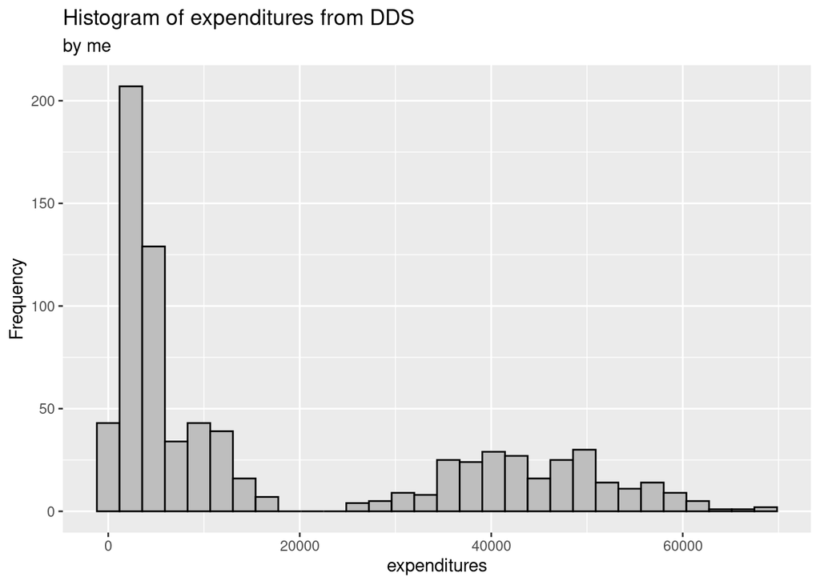

```r
ggplot(data = dds, aes(x = expenditures)) +

  geom_histogram(bins = 30,
                 color = "black",
                 fill = "grey") +

  labs(title = "Histogram of expenditures from DDS",
       subtitle = "by me",
       x = "expenditures",
       y = "Frequency")
```

> **3.** The researchers who collected this data argued Hispanic recipients received significantly less support than White not Hispanic recipients. Create a frequency table that summarizes the number of recipients that fell into each category for the variable `ethnicity`.

```r
table(dds$ethnicity)
```

```
##
##           Hispanic White not Hispanic
##                376                401
```

> **4.** How does the amount of support received differ between “Hispanic” and “White not Hispanic” program recipients? Using, `ggplot()` create side-by-side boxplots of expenditures plotted by ethnicity. In 1 - 2 sentences, answer the following question: *Do these boxplots appear to confirm or contradict the claim that a recipient’s ethnicity is associated with the amount of money the state of California spends on their DDS services and support?*

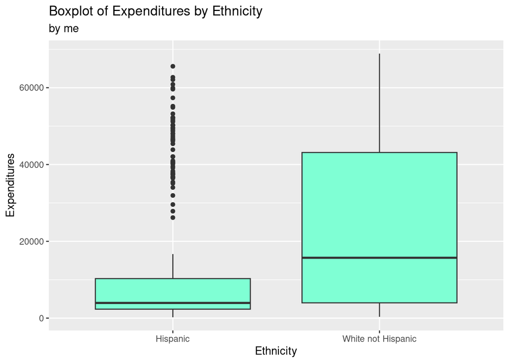

```r
ggplot(data = dds, aes(x = ethnicity, y = expenditures)) +

  geom_boxplot(fill = "aquamarine") +

  labs(title = "Boxplot of Expenditures by Ethnicity",
       subtitle = "by me",
       x = "Ethnicity",
       y = "Expenditures")
```

> **5.** Use the `aggregate()` and `summary()` functions to compute the mean and five-number summary of expedenditures grouped by ethnicity. Remember, the output will not display in your R Markdown document, but it will show up in the knitted html file. Then, compute the difference in the two mean expenditures (White non Hispance minus Hispanic). You may use R or a calculator to compute this value. Report the difference in the two means below.

```r
aggregate(expenditures ~ ethnicity,
          data = dds,
          FUN = summary)
```

```
##            ethnicity expenditures.Min. expenditures.1st Qu. expenditures.Median
## 1           Hispanic            222.00              2331.25             3952.00
## 2 White not Hispanic            340.00              3977.00            15718.00
##   expenditures.Mean expenditures.3rd Qu. expenditures.Max.
## 1          11065.57             10292.50          65581.00
## 2          24697.55             43134.00          68890.00
```

*Answer:* 24697.55 - 11065.57 = 13.631.98 US dollars

> **6.** The variable `age.cohort` assigns recipients to one of six age groups. These cohorts are indicative of particular life phases. In the first three cohorts, recipients are still living with their parents as they move through preschool age, elementary / middle school age, and high school age. In the 18-21 cohort, recipients are transitioning from their parents’ homes to living on their own or in supportive group homes. From ages 22 – 50, individuals are mostly no longer living with their parents but may still receive some support from family. In the 51+ cohort, recipients often have no living parents and typically require the most financial support from DDS. In the first code chunk below, create a bar chart of the variable `age.cohort` using `ggplot()`. Be sure to include an appropriate plot title and appropriate axis labels. In the second code chunk, create a frequency table for the variable.

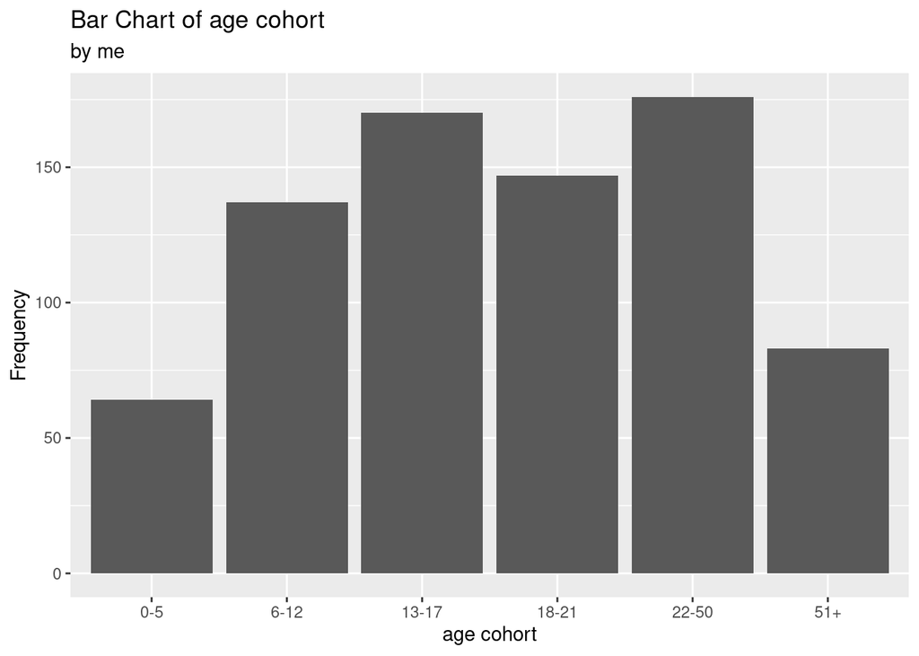

```r
ggplot(data = dds, aes(x = age.cohort)) +

  geom_bar() +

  labs(title = "Bar Chart of age cohort",
       subtitle = "by me",
       x = "age cohort",
       y = "Frequency") +

scale_fill_manual(values = c("darkblue", "purple", "magenta"))
```

```r
table(dds$age.cohort)
```

```
##
##   0-5  6-12 13-17 18-21 22-50   51+
##    64   137   170   147   176    83
```

> **7.** Using, `ggplot()` create side-by-side boxplots of expenditures plotted by `age.cohort`. Be sure to include an appropriate plot title and appropriate axis labels. In 1 - 2 sentences, answer the following question: *Does a recipient’s age group appear to be associated with the amount of money the state of California spends on their DDS services and support?*

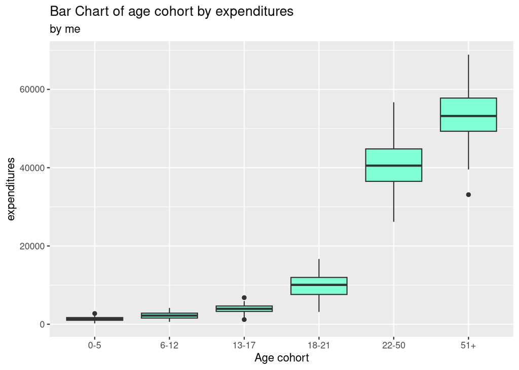

```r
ggplot(data = dds, aes(x = age.cohort, y = expenditures)) +

  geom_boxplot(fill = "aquamarine") +

  labs(title = "Bar Chart of age cohort by expenditures",
       subtitle = "by me",
       x = "Age cohort",
       y = "expenditures")
```

*Answer:* There does seem to be an association between the age cohort and expenditures. On average from the graph the higher the age cohort the more the expenditures are based on the medians. The range of the IQRs also increase as age increases, suggesting more expenditures for higher age cohorts.

> **8.** Use the `aggregate()` and `summary()` functions to compute the mean and five-number summary of expedenditures grouped by age cohort. Remember, the output will not display in your R Markdown document, but it will show up in the knitted html file.

```r
aggregate(expenditures ~ age.cohort,
          data = dds,
          FUN = summary)
```

```
##   age.cohort expenditures.Min. expenditures.1st Qu. expenditures.Median
## 1        0-5           222.000             1012.750            1361.500
## 2       6-12           620.000             1582.000            2212.000
## 3      13-17          1195.000             3281.500            3952.000
## 4      18-21          3157.000             7613.000           10063.000
## 5      22-50         26178.000            36508.000           40531.500
## 6        51+         33110.000            49309.500           53211.000
##   expenditures.Mean expenditures.3rd Qu. expenditures.Max.
## 1          1384.984             1706.250          2750.000
## 2          2224.912             2839.000          4163.000
## 3          3935.212             4665.750          6798.000
## 4         10041.150            11960.500         16677.000
## 5         40367.562            44802.750         56716.000
## 6         53267.386            57790.500         68890.000
```

> **9.** In the first code chunk below, create a stacked bar chart of ethnicity and age cohort. Be sure to include an appropriate plot title and appropriate axis labels. Note: we recommend using `age.cohort` as your `x` variable in the plot. In the second code chunk, create a two-way frequency table for the two variables.

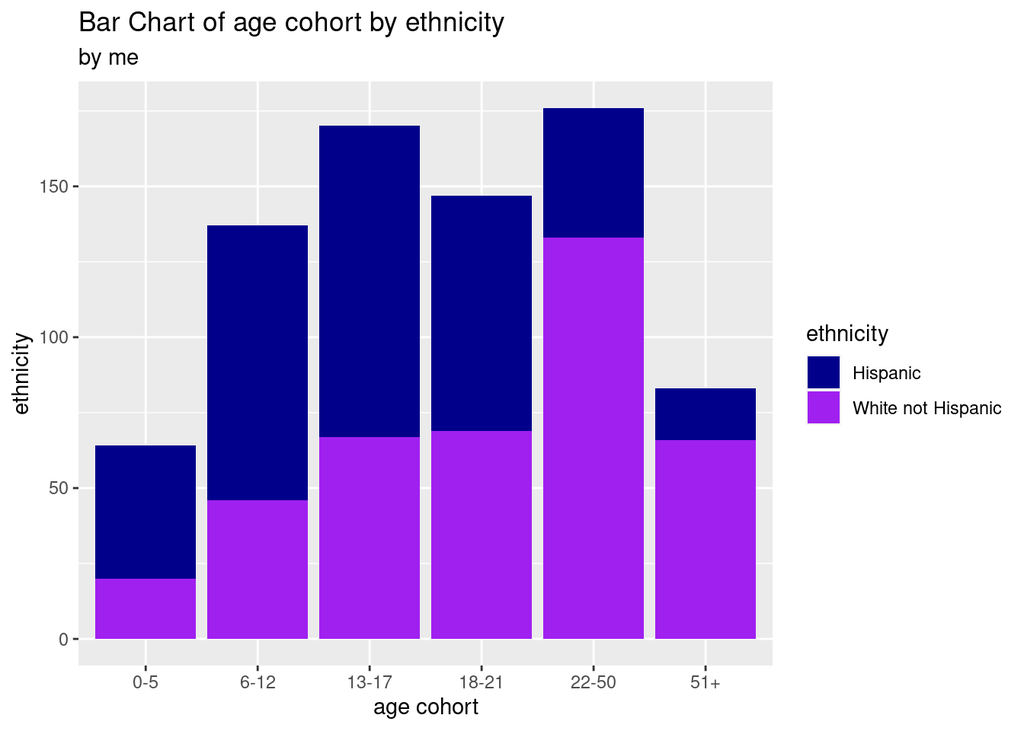

```r
ggplot(data = dds, aes(x = age.cohort, fill = ethnicity)) +

  geom_bar() +

  labs(title = "Bar Chart of age cohort by ethnicity",
       subtitle = "by me",
       x = "age cohort",
       y = "ethnicity") +

scale_fill_manual(values = c("darkblue", "purple"))
```

```r
table(dds$age.cohort, dds$ethnicity)
```

```
##
##         Hispanic White not Hispanic
##   0-5         44                 20
##   6-12        91                 46
##   13-17      103                 67
##   18-21       78                 69
##   22-50       43                133
##   51+         17                 66
```

> **10.** In 2 - 3 sentences, answer the following question: *Do the relationships between age cohort, ethnicity, and expenditures appear to be confounded?* Justify your position by citing patterns in the plots you made throughout the previous exercises, along with any other evidence you believe to be relevant to your decision.

*Answer:* There does seem to be apparent confounding between age cohort and ethnicity. From the graphs we can see that age cohort and ethnicity are related with the trends of the higher age being white ethnicity. The age cohort and expenditures does seem to be confounded with the ethnicity and expenditures because people of higher age tend to get more expenditures than people of lower age, and higher age involved a higher white ethnicity, so both could factor into the expenditures.

### Submission Instructions

Once you have finished, follow the instructions below to submit your work.

1. At the top of the document, update the `author` field. Do not change anything else at the top of the document.
2. Click the Knit button to create an HTML file of your work.
3. In the Files pane (bottom right window), check the box next to `mwrite1supplement.html`.
4. In the Files pane, click on the gear icon (More) and select “Export…”
5. Do not change the file name (`mwrite1supplement.html`). Click Download and save the file to your computer.
6. On the Stats 250 Canvas site, navigate to the MWrite #1 Supplement Work assignment.
7. Upload your saved `mwrite1supplement.html` file.
8. Click “Submit Assignment”. Congratulations, you are done with the fist part of MWrite #1! Note: there will be no file submission for the Lab 3 assignment on Canvas.